# EDA analysis about Employee Attrition by DDSAnalytics

Carlos Estevez

2023-03-31

### **Video presentation**

[Video presentation](https://www.youtube.com/watch?v=8Bq4Du7PY6k)

### **Introduction**

https://www.youtube.com/watch?v=8Bq4Du7PY6k

DDSAnalytics is a company dedicated to conducting data analysis in different areas aiming to help different organizations to streamline their processes and improve their relationship with their business partnes including customers, vendors, and employees.

In this EDA project DDSAnalytics will conduct an analysis for the Frito-lay organization about employee attrition. The Frito-Lay organization has a problem of attrition and they want to identify the reasons behind it. We will investigate the different parameters correlated to attrition and build a model to predict it

**Remember to execute each Chunk in sequence**

[figure not shown]

### **Loading the libraries and initializing**

**It is very important to update the working directory once you download the project!**  
You can use Amazon S3 instead. Take a look at the following section

```r
library(tidyverse)
library(stringr)
library(caret)
library(e1071)
library(class)
library(RCurl)
library(aws.s3)
library(smotefamily)
library(GGally)


file_path = "C:\\Users\\cestevez\\Dropbox\\Cloud PC\\Thinkpad\\Thinkpad Desktop\\Master Data Science SMU\\Class_Sessions\\Data Science Sessions\\Repository\\CaseStudy2DDS\\files\\"
main_data_file = paste0(file_path,"CaseStudy2-data.csv")
main_data_file_noattr = paste0(file_path,"Case2PredictionsCESTEVEZ Attrition.csv")
main_data_file_mi = paste0(file_path,"Case2PredictionsCESTEVEZ Salary.csv")

main_data_file_noattr_source = paste0(file_path,"CaseStudy2CompSet No Attrition.csv")
main_data_file_mi_source = paste0(file_path,"CaseStudy2CompSet No Salary.csv")
```

### **Retrieving data from CSV files**

```r
df_std_1 = read.csv(main_data_file,header = TRUE)
```

### **Retrieving data to Amazon S3**

#### We will read three files from S3

- Main dataset: CaseStudy2-data.csv
- Attrition prediction dataset: CaseStudy2CompSet No Attrition.csv
- Salary prediction dataset: CaseStudy2CompSet No Salary.csv

```r
#Setting the access key and key ids
Sys.setenv("AWS_ACCESS_KEY_ID" = "AKIA5HRB7XJNIOKHMHYK",
           "AWS_SECRET_ACCESS_KEY" = "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",
           "AWS_DEFAULT_REGION"="us-east-2")

#Retrieving three datasets
obj_main_ds = get_object("CaseStudy2-data.csv", bucket = "ddsproject1")
df_std_1=read.csv(text = rawToChar(obj_main_ds), sep=",", header = TRUE)
obj_no_attr = get_object("CaseStudy2CompSet No Attrition.csv", bucket = "ddsproject1")
df_std_nattr=read.csv(text = rawToChar(obj_no_attr), sep=",", header = TRUE)
obj_no_mi = get_object("CaseStudy2CompSet No Salary.csv", bucket = "ddsproject1")
df_std_mi=read.csv(text = rawToChar(obj_no_mi), sep=",", header = TRUE)
```

### **Data manipulation and Oversampling imbalanced data**

```r
#Function for performing oversampling
oversampling = function(p_df_data){
  vlnr_len_0 = nrow(p_df_data)

  df_nos = filter(p_df_data,Attrition == "No")
  df_yeses = filter(p_df_data,Attrition == "Yes")
  vlnr_len_no = nrow(df_nos)
  vlnr_len_yeses = nrow(df_yeses)

  vlnr_balance = vlnr_len_no - vlnr_len_yeses
  df_add_yeses = df_yeses[sample(seq(1,vlnr_len_yeses,1),vlnr_balance,replace = TRUE),]
  df_new_yeses = rbind(df_yeses,df_add_yeses)
  df_final = rbind(df_new_yeses,df_nos)
  return(df_final)
}


#Categorical variables to Factor
df_std_1$BusinessTravel = factor(df_std_1$BusinessTravel)
df_std_1$Attrition = factor(df_std_1$Attrition)
df_std_1$Department = factor(df_std_1$Department)
df_std_1$Education = factor(df_std_1$Education)
df_std_1$EducationField = factor(df_std_1$EducationField)
df_std_1$EnvironmentSatisfaction = factor(df_std_1$EnvironmentSatisfaction)
df_std_1$Gender = factor(df_std_1$Gender)
df_std_1$JobLevel0 = factor(df_std_1$JobLevel)
df_std_1$JobLevel = factor(df_std_1$JobLevel,levels = c(5,4,3,2,1),labels = c("Senior management","Middle management","First-level management","Intermediate or experienced","Entry-level"))
df_std_1$JobRole = factor(df_std_1$JobRole)
df_std_1$JobInvolvement = factor(df_std_1$JobInvolvement)
df_std_1$JobSatisfaction = factor(df_std_1$JobSatisfaction)
df_std_1$MaritalStatus = factor(df_std_1$MaritalStatus)
df_std_1$OverTime = factor(df_std_1$OverTime)
df_std_1$RelationshipSatisfaction = factor(df_std_1$RelationshipSatisfaction)
df_std_1$Over18 = factor(df_std_1$Over18)
df_std_1$StockOptionLevel = factor(df_std_1$StockOptionLevel)

#Categorical variables to numeric
df_std_1$JobSatisfactionN = factor(df_std_1$JobSatisfaction)
df_std_1$EnvironmentSatisfactionN = factor(df_std_1$EnvironmentSatisfaction)
df_std_1$OverTimeN = as.numeric(df_std_1$OverTime)
df_std_1$MaritalStatusN = as.numeric(df_std_1$MaritalStatus)
df_std_1$JobRoleN = as.numeric(df_std_1$JobRole)
df_std_1$JobLevelN = as.numeric(df_std_1$JobLevel)
df_std_1$JobLevelN2 = as.numeric(df_std_1$JobLevel0)
df_std_1$GendeN = as.numeric(df_std_1$Gender)
df_std_1$BusinessTravelN = as.numeric(df_std_1$BusinessTravel)
df_std_1$AttritionN = as.numeric(df_std_1$Attrition)
df_std_1$StockOptionLevelN = as.numeric(df_std_1$StockOptionLevel)
df_std_1$JobInvolvementN = as.numeric(df_std_1$JobSatisfactionN)

#Continuous variables to numeric
df_std_1$MonthlyIncome = as.numeric(df_std_1$MonthlyIncome)
df_std_1$DistanceFromHome = as.numeric(df_std_1$DistanceFromHome)
df_std_1$YearsInCurrentRole = as.numeric(df_std_1$YearsInCurrentRole)
df_std_1$YearsAtCompany = as.numeric(df_std_1$YearsAtCompany)
df_std_1$YearsWithCurrManager = as.numeric(df_std_1$YearsWithCurrManager)
df_std_1$EmployeeNumber = as.numeric(df_std_1$EmployeeNumber)
df_std_1$TotalWorkingYears = as.numeric(df_std_1$TotalWorkingYears)
df_std_1$Age = as.numeric(df_std_1$Age)


#Performing oversampling
df_std_unp = oversampling(df_std_1)
df_std_unp$MonthlyIncomeScaled = scale(df_std_unp$MonthlyIncome) #/ 100
#Setting the data for the model
df_data_model_0 = select(df_std_unp,Attrition,MonthlyIncomeScaled,OverTimeN,JobLevelN,StockOptionLevelN,MaritalStatusN,YearsAtCompany,JobSatisfactionN)
```

### **Data Exploration**

#### First we will analyze the continous variables and then the categorical variables

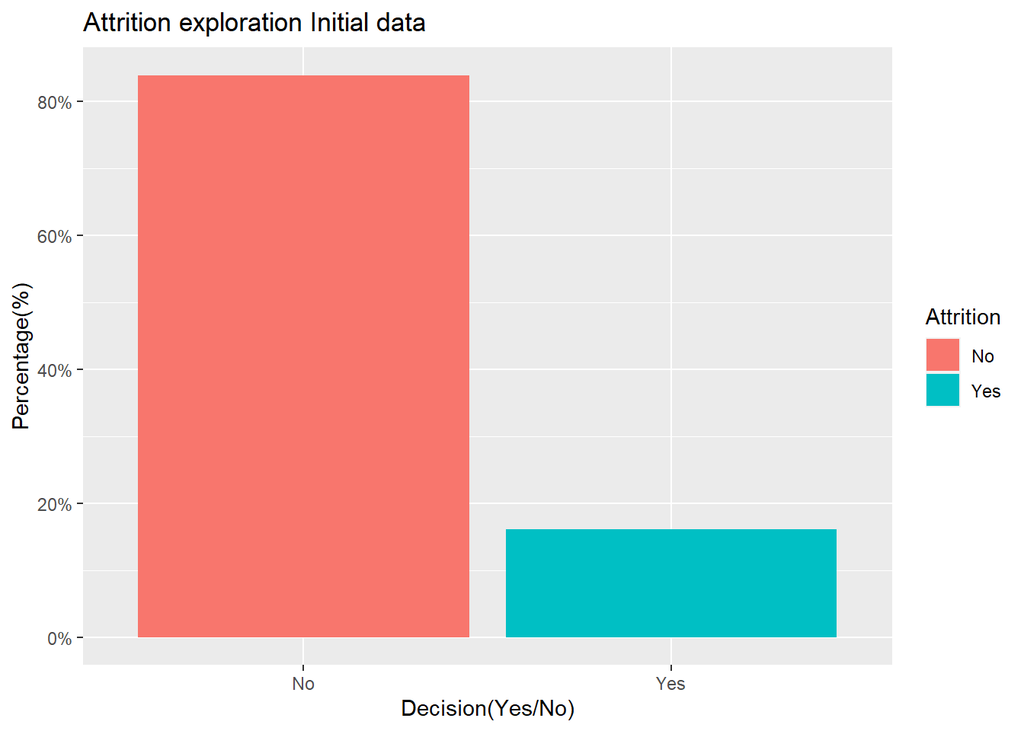

```r
#Before oversampling
df_perc_1 = df_std_1 %>% count(Attrition) %>% mutate(perc=(n/(nrow(df_std_1)))*1)
df_perc_1 %>% ggplot(aes(x=Attrition,y=perc,fill=Attrition))+geom_bar(stat="identity")+
  labs(title="Attrition exploration Initial data",y="Percentage(%)",x="Decision(Yes/No)")+scale_y_continuous(labels=scales::percent)
```

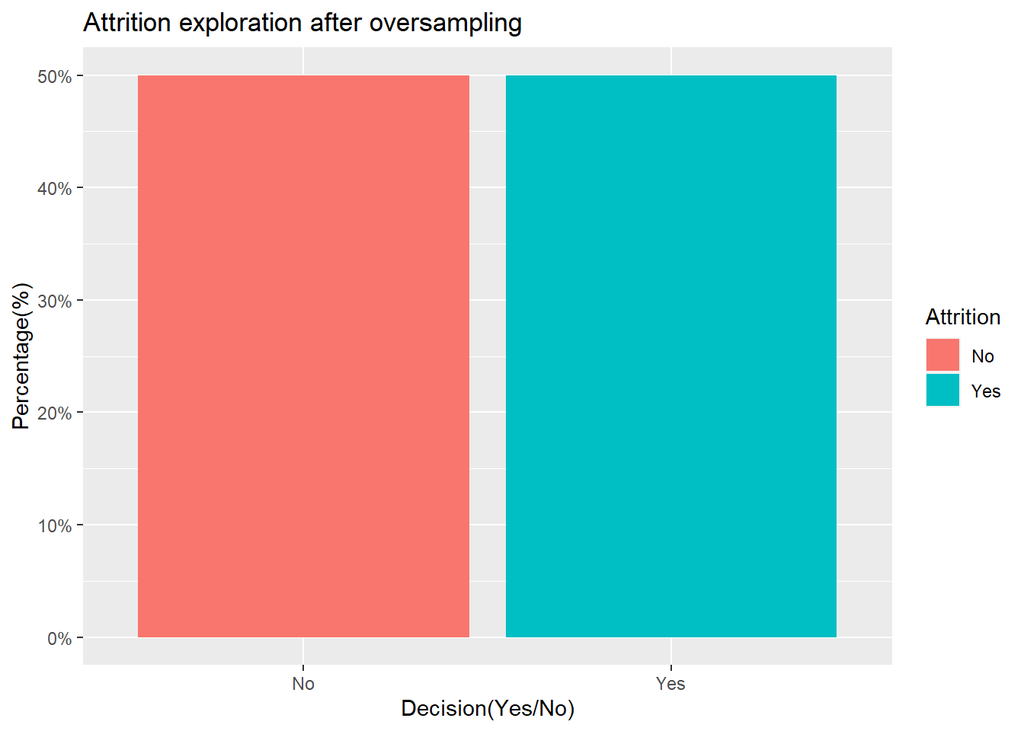

```r
#Data after oversampling
df_perc_1 = df_std_unp %>% count(Attrition) %>% mutate(perc=(n/(nrow(df_std_unp)))*1)
df_perc_1 %>% ggplot(aes(x=Attrition,y=perc,fill=Attrition))+geom_bar(stat="identity")+
  labs(title="Attrition exploration after oversampling",y="Percentage(%)",x="Decision(Yes/No)")+scale_y_continuous(labels=scales::percent)
```

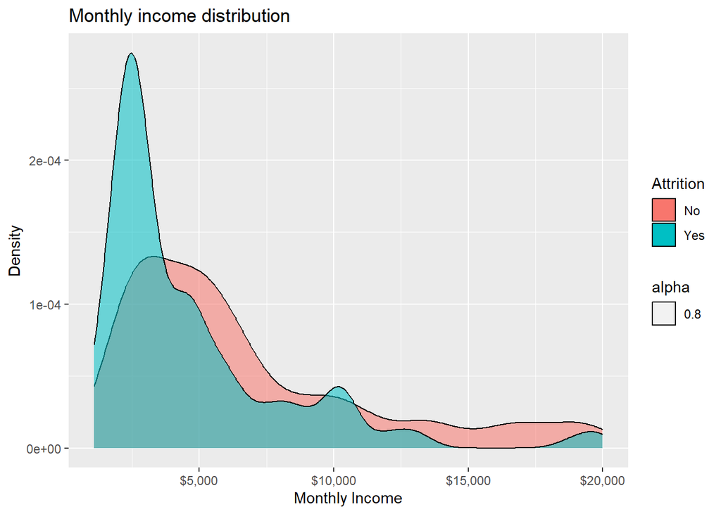

```r
#MonthlyIncome
df_std_unp %>% ggplot(aes(x=MonthlyIncome))+geom_density(aes(fill=Attrition,alpha=0.8))+labs(title="Monthly income distribution",y="Density",x="Monthly Income")+scale_x_continuous(labels=scales::dollar)
```

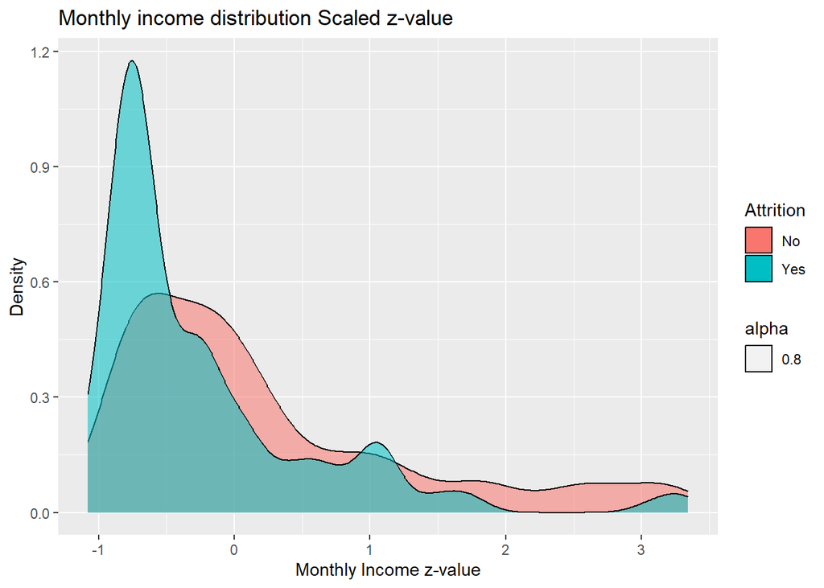

```r
df_std_unp %>% ggplot(aes(x=MonthlyIncomeScaled))+geom_density(aes(fill=Attrition,alpha=0.8))+labs(title="Monthly income distribution Scaled z-value",y="Density",x="Monthly Income z-value")
```

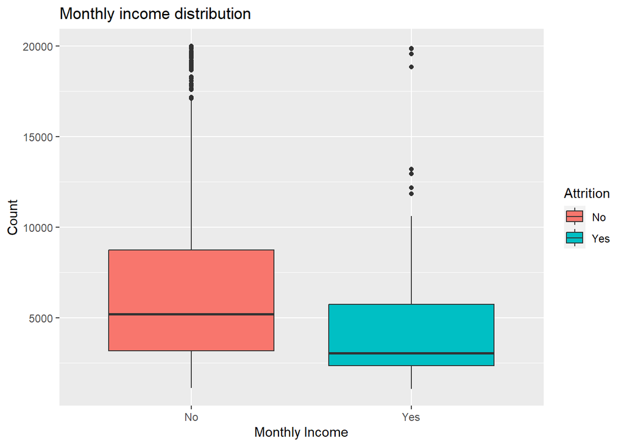

```r
df_std_unp %>% ggplot(aes(x=Attrition,y=MonthlyIncome))+geom_boxplot(aes(fill=Attrition))+
  labs(title="Monthly income distribution",y="Count",x="Monthly Income")
```

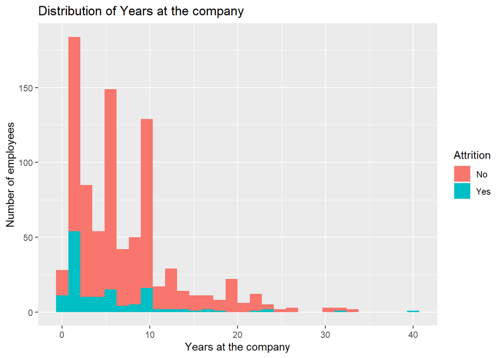

```r
#YearsAtCompany
df_std_1 %>% ggplot(aes(x=YearsAtCompany))+geom_histogram(aes(fill=Attrition))+
  labs(title="Distribution of Years at the company",y="Number of employees",x="Years at the company")
```

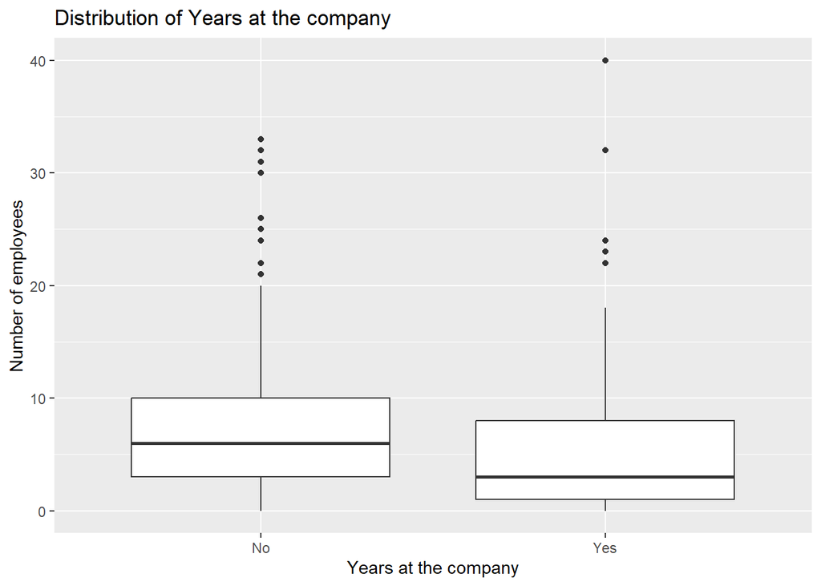

```r
df_std_1 %>% ggplot(aes(x=Attrition,y=YearsAtCompany))+geom_boxplot()+
  labs(title="Distribution of Years at the company",y="Number of employees",x="Years at the company")
```

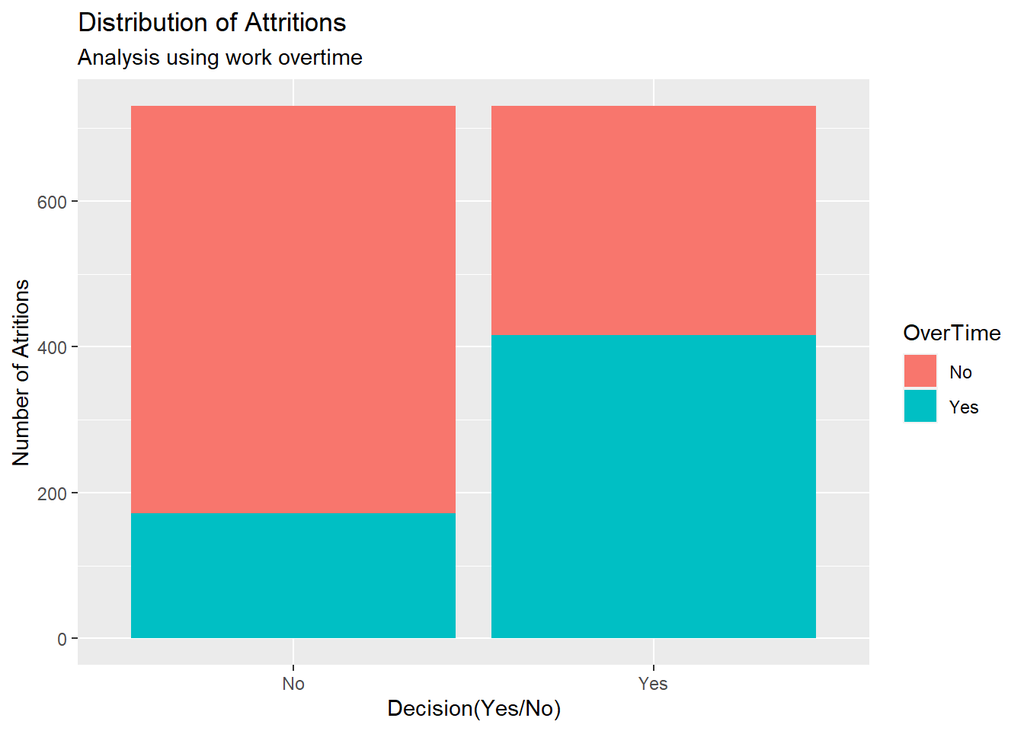

```r
#Ploting categorical variables


#Overtime
df_std_unp %>% ggplot(aes(x=Attrition,fill=OverTime))+geom_bar()+
labs(title="Distribution of Attritions",subtitle = "Analysis using work overtime",y="Number of Atritions",x="Decision(Yes/No)")
```

```r
result_table = table(df_std_unp$OverTime,df_std_unp$Attrition)
round(prop.table(result_table,margin = 1)*100,2)
```

```
##
##          No   Yes
##   No  63.99 36.01
##   Yes 29.25 70.75
```

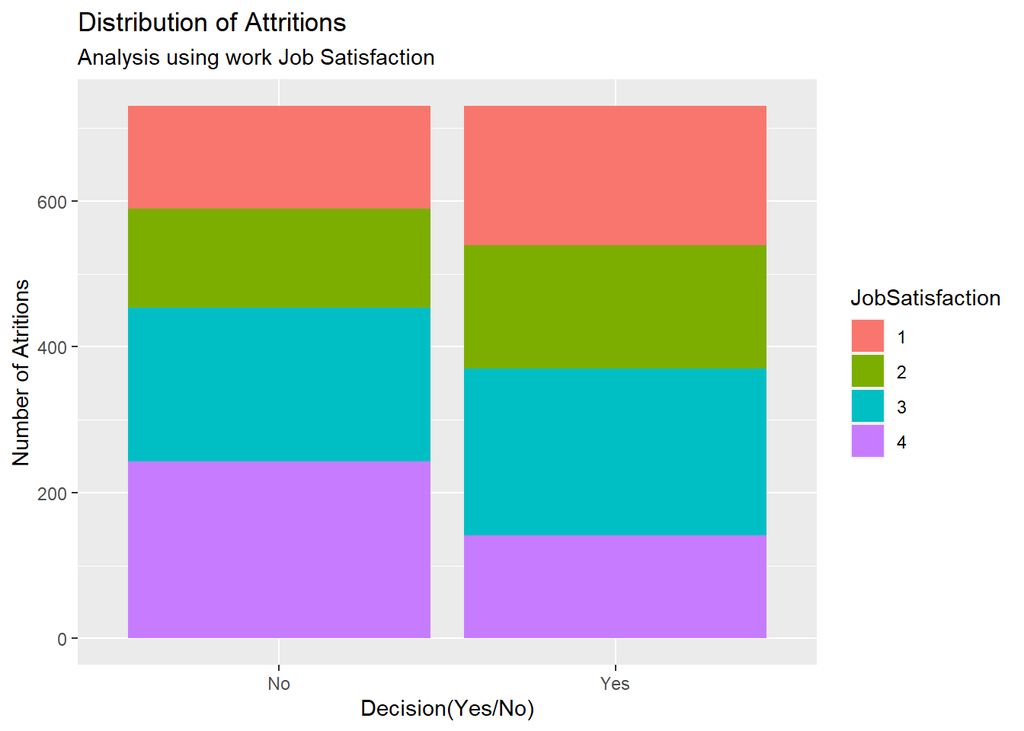

```r
#Job Staisfaction
df_std_unp %>% ggplot(aes(x=Attrition,fill=JobSatisfaction))+geom_bar()+
labs(title="Distribution of Attritions",subtitle = "Analysis using work Job Satisfaction",y="Number of Atritions",x="Decision(Yes/No)")
```

```r
result_table = table(df_std_unp$JobSatisfaction,df_std_unp$Attrition)
round(prop.table(result_table,margin = 2)*100,2)
```

```
##
##        No   Yes
##   1 19.32 26.16
##   2 18.49 23.15
##   3 28.90 31.37
##   4 33.29 19.32
```

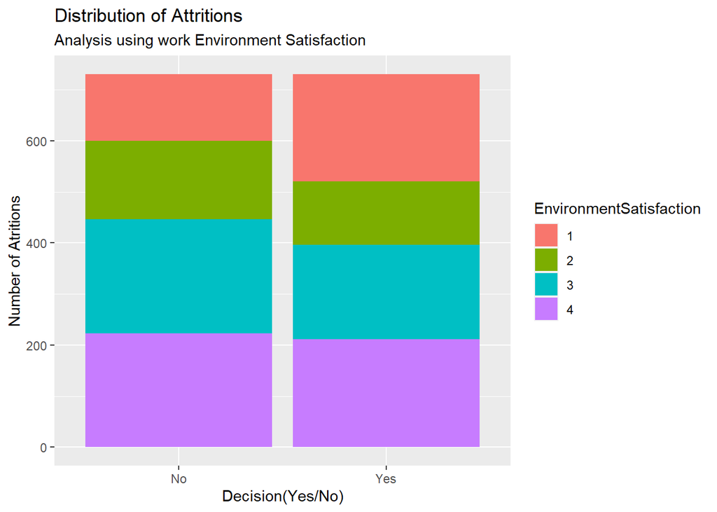

```r
#Env.Satisfaction
df_std_unp %>% ggplot(aes(x=Attrition,fill=EnvironmentSatisfaction))+geom_bar()+labs(title="Distribution of Attritions",subtitle = "Analysis using work Environment Satisfaction",y="Number of Atritions",x="Decision(Yes/No)")
```

```r
result_table = table(df_std_unp$EnvironmentSatisfaction,df_std_unp$Attrition)
round(prop.table(result_table,margin = 2)*100,2)
```

```
##
##        No   Yes
##   1 17.81 28.77
##   2 21.10 16.99
##   3 30.55 25.34
##   4 30.55 28.90
```

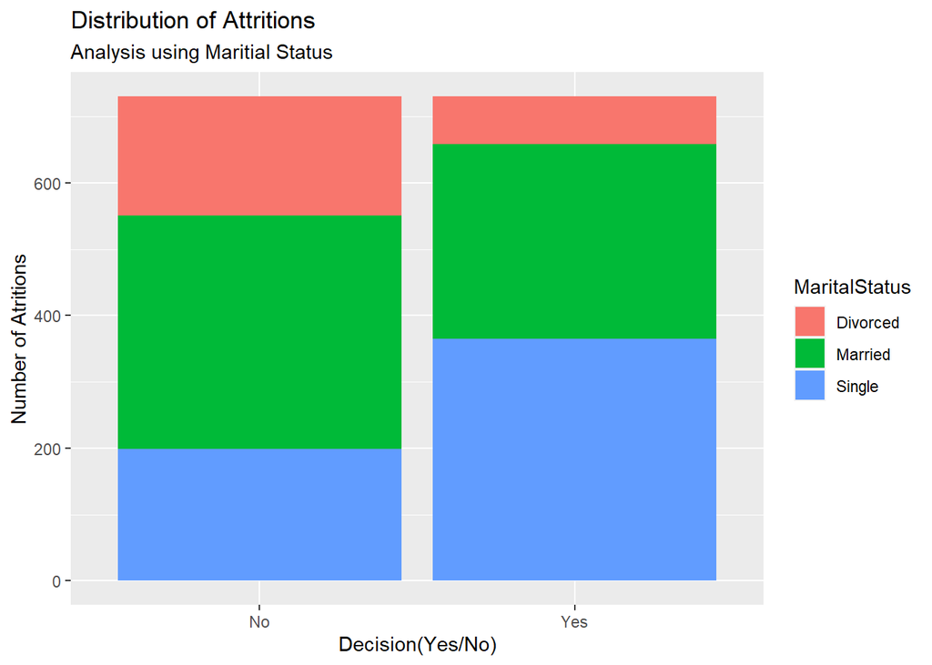

```r
#Maritial Status
df_std_unp %>% ggplot(aes(x=Attrition,fill=MaritalStatus))+geom_bar()+labs(title="Distribution of Attritions",subtitle = "Analysis using Maritial Status",y="Number of Atritions",x="Decision(Yes/No)")
```

```r
result_table = table(df_std_unp$MaritalStatus,df_std_unp$Attrition)
round(prop.table(result_table,margin = 2)*100,2)
```

```
##
##               No   Yes
##   Divorced 24.52  9.86
##   Married  48.22 40.14
##   Single   27.26 50.00
```

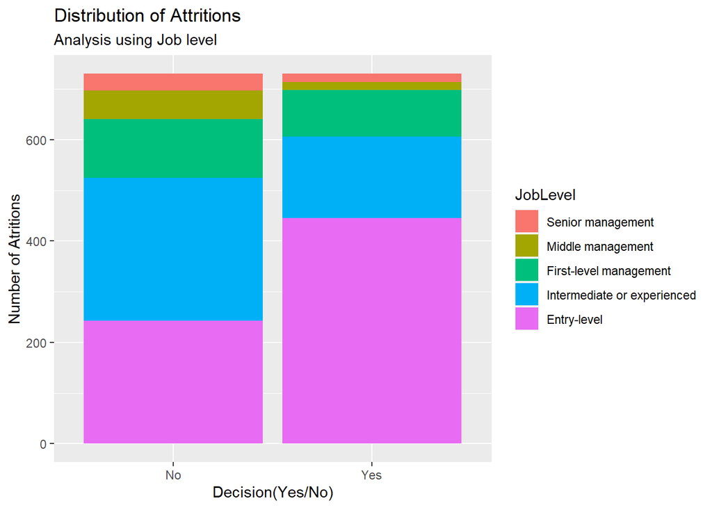

```r
  #Job Level
  df_std_unp %>% ggplot(aes(x=Attrition,fill=JobLevel))+geom_bar()+labs(title="Distribution of Attritions",subtitle = "Analysis using Job level",y="Number of Atritions",x="Decision(Yes/No)")
```

```r
  result_table = table(df_std_unp$JobLevel,df_std_unp$Attrition)
  round(prop.table(result_table,margin = 2)*100,2)
```

```
##
##                                  No   Yes
##   Senior management            4.52  2.19
##   Middle management            7.81  2.19
##   First-level management      15.75 12.60
##   Intermediate or experienced 38.63 22.05
##   Entry-level                 33.29 60.96
```

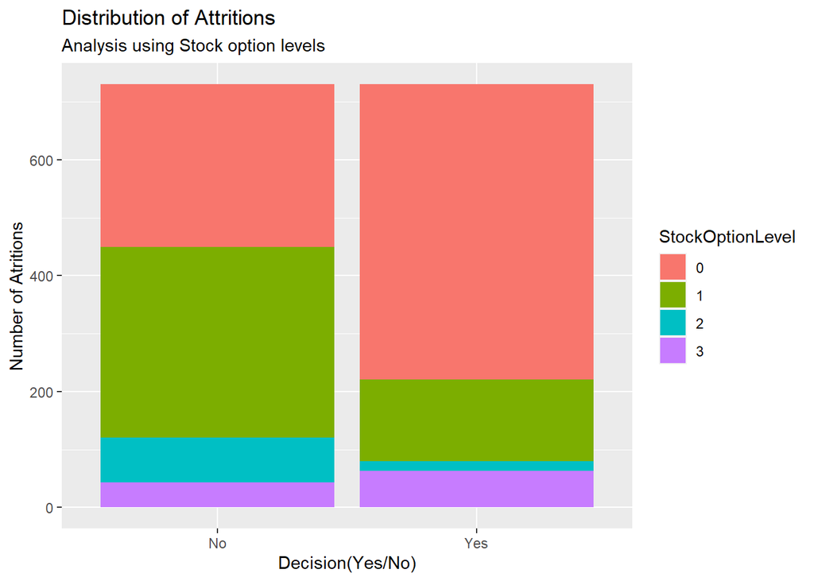

```r
#Stock Option Level
df_std_unp %>% ggplot(aes(x=Attrition,fill=StockOptionLevel))+geom_bar()+labs(title="Distribution of Attritions",subtitle = "Analysis using Stock option levels",y="Number of Atritions",x="Decision(Yes/No)")
```

```r
result_table = table(df_std_unp$StockOptionLevel,df_std_unp$Attrition)
round(prop.table(result_table,margin = 2)*100,2)
```

```
##
##        No   Yes
##   0 38.49 69.73
##   1 44.93 19.32
##   2 10.68  2.33
##   3  5.89  8.63
```

```r
# #Variables selected
# #MonthlyIncome, YearsAtCompany, OverTimeN, JobLevelN, JobSatisfactionN, MaritalStatusN, StockOptionLevelN
#
# df_data_model_0 = select(df_std_unp,Attrition,MonthlyIncome,YearsAtCompany,OverTimeN,JobLevelN,MaritalStatusN,StockOptionLevelN,JobSatisfactionN)
#
```

### **Feature selection Categorical Data using Chi-square test**

#### Previously we analyzed the different relevant features by visualizing the data. In this section we will corroborate that information using Chi-Square test. We will Keep values in the model when p-value is less than 0.05

```r
#Categorical feature selection
df_var_cat_imp = data.frame(var_name = character(16),importance = numeric(16))

df_var_cat_imp$var_name[1] = 'BusinessTravel'
df_var_cat_imp$importance[1] = chisq.test(df_std_1$BusinessTravel, df_std_1$Attrition)$p.value

df_var_cat_imp$var_name[2] = 'Department'
df_var_cat_imp$importance[2] = chisq.test(df_std_1$Department, df_std_1$Attrition)$p.value

df_var_cat_imp$var_name[3] = 'Education'
df_var_cat_imp$importance[3] = chisq.test(df_std_1$Education, df_std_1$Attrition)$p.value
df_var_cat_imp$var_name[4] = 'EducationField'
df_var_cat_imp$importance[4] = chisq.test(df_std_1$EducationField, df_std_1$Attrition)$p.value
df_var_cat_imp$var_name[5] = 'EnvironmentSatisfaction'
df_var_cat_imp$importance[5] = chisq.test(df_std_1$EnvironmentSatisfaction, df_std_1$Attrition)$p.value

df_var_cat_imp$var_name[6] = 'Gender'
df_var_cat_imp$importance[6] = chisq.test(df_std_1$Gender, df_std_1$Attrition)$p.value

df_var_cat_imp$var_name[7] = 'JobInvolvement'
df_var_cat_imp$importance[7] = chisq.test(df_std_1$JobInvolvement, df_std_1$Attrition)$p.value

df_var_cat_imp$var_name[8] = 'JobLevel'
df_var_cat_imp$importance[8] = chisq.test(df_std_1$JobLevel, df_std_1$Attrition)$p.value

df_var_cat_imp$var_name[9] = 'JobRole'
df_var_cat_imp$importance[9] = chisq.test(df_std_1$JobRole, df_std_1$Attrition)$p.value
df_var_cat_imp$var_name[10] = 'JobSatisfaction'
df_var_cat_imp$importance[10] = chisq.test(df_std_1$JobSatisfaction, df_std_1$Attrition)$p.value

df_var_cat_imp$var_name[11] = 'MaritalStatus'
df_var_cat_imp$importance[11] = chisq.test(df_std_1$MaritalStatus, df_std_1$Attrition)$p.value

df_var_cat_imp$var_name[12] = 'PerformanceRating'
df_var_cat_imp$importance[12] = chisq.test(df_std_1$PerformanceRating, df_std_1$Attrition)$p.value

df_var_cat_imp$var_name[13] = 'OverTime'
df_var_cat_imp$importance[13] = chisq.test(df_std_1$OverTime, df_std_1$Attrition)$p.value


df_var_cat_imp$var_name[14] = 'RelationshipSatisfaction'
df_var_cat_imp$importance[14] = chisq.test(df_std_1$RelationshipSatisfaction, df_std_1$Attrition)$p.value

df_var_cat_imp$var_name[15] = 'StockOptionLevel'
df_var_cat_imp$importance[15] = chisq.test(df_std_1$StockOptionLevel, df_std_1$Attrition)$p.value

df_var_cat_imp$var_name[16] = 'WorkLifeBalance'
df_var_cat_imp$importance[16] = chisq.test(df_std_1$WorkLifeBalance, df_std_1$Attrition)$p.value


df_var_cat_imp  = arrange(df_var_cat_imp, desc(importance))
df_var_cat_imp
```

```
##                    var_name   importance
## 1         PerformanceRating 7.461706e-01
## 2                 Education 6.242838e-01
## 3                    Gender 5.151297e-01
## 4  RelationshipSatisfaction 3.727117e-01
## 5            EducationField 2.682198e-01
## 6            BusinessTravel 4.992536e-02
## 7           JobSatisfaction 1.115122e-02
## 8   EnvironmentSatisfaction 1.054090e-02
## 9                Department 9.423773e-03
## 10          WorkLifeBalance 2.495090e-03
## 11            MaritalStatus 3.378946e-08
## 12                 JobLevel 2.084703e-08
## 13           JobInvolvement 5.211041e-09
## 14                  JobRole 3.646836e-10
## 15         StockOptionLevel 3.724464e-12
## 16                 OverTime 2.332981e-15
```

### **KNN Model**

Parameters

- Percentage Training data and Testing data: 75
- Iterations to find best K: 20

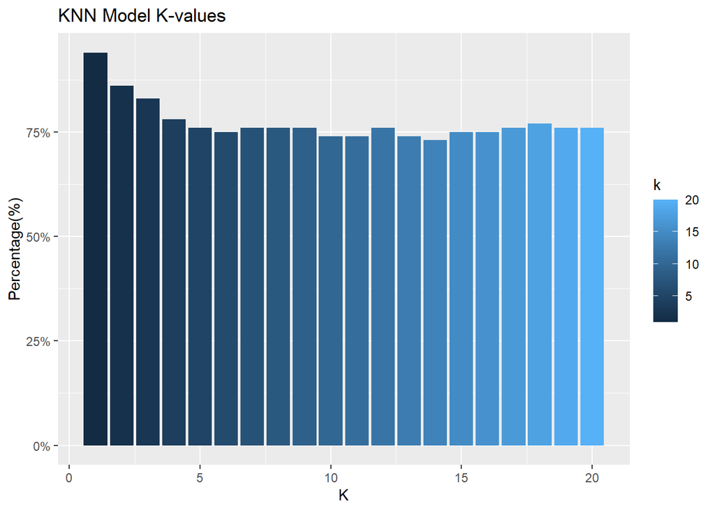

  ```r
  #Setting training and Testing data
  nr_percentage = 75
  nr_len = nrow(df_data_model_0)
  nr_len = nrow(df_data_model_0)
  df_samples = sample(1:nr_len,round(nr_len*(nr_percentage/100)))
  df_lst_train = df_data_model_0[df_samples,]
  df_lst_test = df_data_model_0[-df_samples,]


  #Iterations
  lst_ki_index = 20
  lst_knn_data = data.frame(k=numeric(lst_ki_index) ,accuracy=numeric(lst_ki_index) )

  #Finding the best K
  for(ki in 1:lst_ki_index){
    knn_results = knn(df_lst_train[,c(2:8)], df_lst_test[,c(2:8)], df_lst_train$Attrition, k = ki, prob = TRUE)
    table_result = table(knn_results,df_lst_test$Attrition)
    co_matrix  = confusionMatrix(table_result)
    lst_knn_data$k[ki] = ki
    lst_knn_data$accuracy[ki] = round(co_matrix$overall[1],2)
  }

  lst_knn_data %>% ggplot(aes(x=k,y=accuracy,fill=k))+geom_bar(stat="identity")+
    scale_y_continuous(labels=scales::percent)+labs(title="KNN Model K-values",
                                                    x="K",y="Percentage(%)")
  ```

  ```r
  #Selected model, K = 3
  knn_results = knn(df_lst_train[,c(2:8)], df_lst_test[,c(2:8)], df_lst_train$Attrition, k = 3, prob = TRUE)
  table_result = table(knn_results,df_lst_test$Attrition)
  confusionMatrix(table_result)
  ```

  ```
  ## Confusion Matrix and Statistics
  ##
  ##
  ## knn_results  No Yes
  ##         No  117   9
  ##         Yes  54 185
  ##
  ##                Accuracy : 0.8274
  ##                  95% CI : (0.7846, 0.8647)
  ##     No Information Rate : 0.5315
  ##     P-Value [Acc > NIR] : < 2.2e-16
  ##
  ##                   Kappa : 0.6479
  ##
  ##  Mcnemar's Test P-Value : 2.965e-08
  ##
  ##             Sensitivity : 0.6842
  ##             Specificity : 0.9536
  ##          Pos Pred Value : 0.9286
  ##          Neg Pred Value : 0.7741
  ##              Prevalence : 0.4685
  ##          Detection Rate : 0.3205
  ##    Detection Prevalence : 0.3452
  ##       Balanced Accuracy : 0.8189
  ##
  ##        'Positive' Class : No
  ##
  ```

### **Naive Bayes Model**

```r
#Setting training and Testing data
nr_percentage = 75
nr_len = nrow(df_data_model_0)
df_samples = sample(1:nr_len,round(nr_len*(nr_percentage/100)))
df_lst_train = df_data_model_0[df_samples,]
df_lst_test = df_data_model_0[-df_samples,]

#Running the model
model_nb = naiveBayes(df_lst_train[,c(2:8)],df_lst_train$Attrition)
predict_nb = predict(model_nb,df_lst_test[,c(2:8)])
result_table = table(predict_nb,df_lst_test$Attrition)
confusionMatrix(result_table)
```

```
## Confusion Matrix and Statistics
##
##
## predict_nb  No Yes
##        No  109  34
##        Yes  71 151
##
##                Accuracy : 0.7123
##                  95% CI : (0.6629, 0.7583)
##     No Information Rate : 0.5068
##     P-Value [Acc > NIR] : 1.104e-15
##
##                   Kappa : 0.4229
##
##  Mcnemar's Test P-Value : 0.0004427
##
##             Sensitivity : 0.6056
##             Specificity : 0.8162
##          Pos Pred Value : 0.7622
##          Neg Pred Value : 0.6802
##              Prevalence : 0.4932
##          Detection Rate : 0.2986
##    Detection Prevalence : 0.3918
##       Balanced Accuracy : 0.7109
##
##        'Positive' Class : No
##
```

### **Logistic Regression Model**

The performance of this model is very low

```r
glm_model = glm(Attrition~MonthlyIncomeScaled+YearsAtCompany+OverTimeN+JobLevelN+JobSatisfactionN+MaritalStatusN+StockOptionLevelN,family = "binomial", data = df_lst_train)
glm_results = predict(glm_model,data=df_lst_test,type='response')
predicted.classes <- ifelse(glm_results> 0.5, "Yes", "No")
mean(predicted.classes == df_lst_test$Attrition)
```

```
## [1] 0.5086758
```

### **Feature selection for Linear RegressionModel**

```r
data_cor = select(df_std_1,MonthlyIncome,JobLevelN2,JobRoleN,YearsAtCompany,GendeN,TotalWorkingYears,BusinessTravelN,AttritionN)
data_cor_res = cor(data_cor)
data_cor_res
```

```
##                   MonthlyIncome  JobLevelN2    JobRoleN YearsAtCompany
## MonthlyIncome        1.00000000  0.95164005 -0.07516553    0.491378966
## JobLevelN2           0.95164005  1.00000000 -0.07429945    0.520583507
## JobRoleN            -0.07516553 -0.07429945  1.00000000   -0.091223937
## YearsAtCompany       0.49137897  0.52058351 -0.09122394    1.000000000
## GendeN              -0.05515709 -0.06907846 -0.01788214   -0.081819101
## TotalWorkingYears    0.77851121  0.78075235 -0.13312291    0.636083586
## BusinessTravelN      0.06270690  0.03051233 -0.02428547   -0.002015983
## AttritionN          -0.15491496 -0.16213644  0.09053860   -0.128754060
##                         GendeN TotalWorkingYears BusinessTravelN   AttritionN
## MonthlyIncome     -0.055157089        0.77851121     0.062706904 -0.154914955
## JobLevelN2        -0.069078459        0.78075235     0.030512330 -0.162136444
## JobRoleN          -0.017882143       -0.13312291    -0.024285473  0.090538602
## YearsAtCompany    -0.081819101        0.63608359    -0.002015983 -0.128754060
## GendeN             1.000000000       -0.07237495    -0.006191567  0.025250336
## TotalWorkingYears -0.072374947        1.00000000     0.033854541 -0.167206122
## BusinessTravelN   -0.006191567        0.03385454     1.000000000 -0.006125598
## AttritionN         0.025250336       -0.16720612    -0.006125598  1.000000000
```

### **Linear Regression Model**

Parameters

- JobLevel
- YearsAtCompany
- Working years

```r
nr_att = nrow(df_std_1)
nr_per = 0.75
lst_index = sample(nr_att,round(nr_att*nr_per))


df_std_train_m1 = df_std_1[lst_index,]
df_std_test_m1 = df_std_1[-lst_index,]

#Fitting the model
lm_model_0 = lm(MonthlyIncome~JobLevelN2+YearsAtCompany+TotalWorkingYears,data = df_std_train_m1)
lm_model_pre_0 = predict(lm_model_0,newdata = df_std_test_m1)
df_mspe_model_0 = data.frame(JobLevelN = df_std_test_m1$JobLevelN2,Observed = df_std_test_m1$MonthlyIncome,Predicted = lm_model_pre_0)
df_mspe_model_0$Residual = df_mspe_model_0$Observed - df_mspe_model_0$Predicted
df_mspe_model_0$IMAPE = abs( df_mspe_model_0$Residual / df_mspe_model_0$Observed )
df_mspe_model_0$SquareResidual = df_mspe_model_0$Residual^2

nr_mspe_model_0 = mean(df_mspe_model_0$SquareResidual)
nr_mspe_model_1 = mean(df_mspe_model_0$IMAPE) * 100
nr_mspe_model_rmse = sqrt(mean(df_mspe_model_0$SquareResidual))

sprintf("MAPE: %f",nr_mspe_model_1)
```

```
## [1] "MAPE: 18.992710"
```

```r
sprintf("RMSE: %f",nr_mspe_model_rmse)
```

```
## [1] "RMSE: 1324.642402"
```

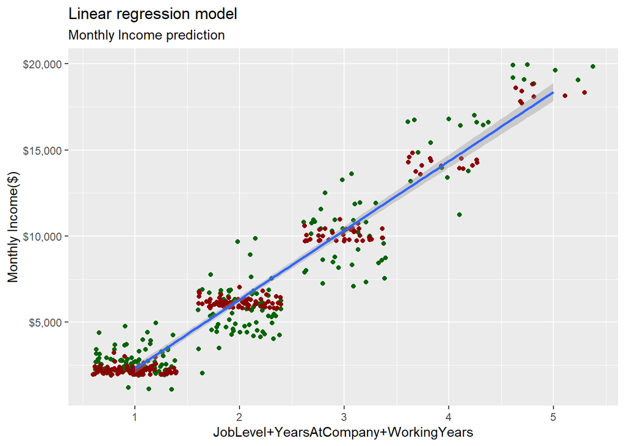

```r
df_mspe_model_0 %>% ggplot()+geom_jitter(aes(x=JobLevelN,y=Observed),color="darkgreen")+
  geom_jitter(aes(x=JobLevelN,y=Predicted),color="darkred")+scale_y_continuous(labels=scales::dollar)+geom_smooth(method = "lm",aes(x=JobLevelN,y=Observed))+labs(title = "Linear regression model",subtitle = "Monthly Income prediction",x="JobLevel+YearsAtCompany+WorkingYears",y="Monthly Income($)")
```

### **Predict Attrition using S3 DS**

Predicting attrition from file: CaseStudy2CompSet No Attrition.csv

#### KNN detail

- K = 3

**Parameters**

- MonthlyIncomeScaled
- YearsAtCompany
- OverTimeN
- JobLevelN
- JobSatisfactionN
- MaritalStatusN
- StockOptionLevelN

```r
#Setting the data for the model
df_predict_ds = df_std_nattr

#Transforming categorical variables to numeric

df_predict_ds$ID =  df_std_nattr$ID
df_predict_ds$YearsAtCompany = as.numeric(df_predict_ds$YearsAtCompany)
df_predict_ds$OverTime = factor(df_predict_ds$OverTime)
df_predict_ds$OverTimeN = as.numeric(df_predict_ds$OverTime)
df_predict_ds$JobLevel = factor(df_predict_ds$JobLevel)
df_predict_ds$JobLevelN = as.numeric(df_predict_ds$JobLevel)
df_predict_ds$JobSatisfaction = factor(df_predict_ds$JobSatisfaction)
df_predict_ds$JobSatisfactionN = as.numeric(df_predict_ds$JobSatisfaction)
df_predict_ds$MaritalStatus = factor(df_predict_ds$MaritalStatus)
df_predict_ds$MaritalStatusN = as.numeric(df_predict_ds$MaritalStatus)
df_predict_ds$StockOptionLevel = factor(df_predict_ds$StockOptionLevel)
df_predict_ds$StockOptionLevelN = as.numeric(df_predict_ds$StockOptionLevel)
v_mean_monthincome = mean(df_std_unp$MonthlyIncome)
v_sd_monthlyincome = sd(df_std_unp$MonthlyIncome)
df_predict_ds = mutate(df_predict_ds,MonthlyIncomeScaled=((MonthlyIncome-v_mean_monthincome)/v_sd_monthlyincome))


ds_predict_model_0 = select(df_predict_ds,MonthlyIncomeScaled,YearsAtCompany,OverTimeN,JobLevelN,MaritalStatusN,StockOptionLevelN,JobSatisfactionN)

#df_predict_ds$MonthlyIncomeScale = scale(df_predict_ds$MonthlyIncome)


#Running the model
knn_nattr = knn(df_data_model_0[,c(2:8)], ds_predict_model_0, df_data_model_0$Attrition, k = 3,prob = TRUE)
#Final result
df_knn_nattr = data.frame(EmployeeId = df_std_nattr$ID,JobLevel=df_std_nattr$JobLevel,OverTime = df_std_nattr$OverTime,MonthlyIncome=df_std_nattr$MonthlyIncome,YearsAtCompany=df_std_nattr$YearsAtCompany,JobSatisfaction=df_std_nattr$JobSatisfaction,MaritalStatus=df_std_nattr$MaritalStatus,StockOptionLevel=df_std_nattr$StockOptionLevel,Attrition=knn_nattr)

table(df_knn_nattr$OverTime,df_knn_nattr$Attrition)
```

```
##
##        No Yes
##   No   78 134
##   Yes  36  52
```

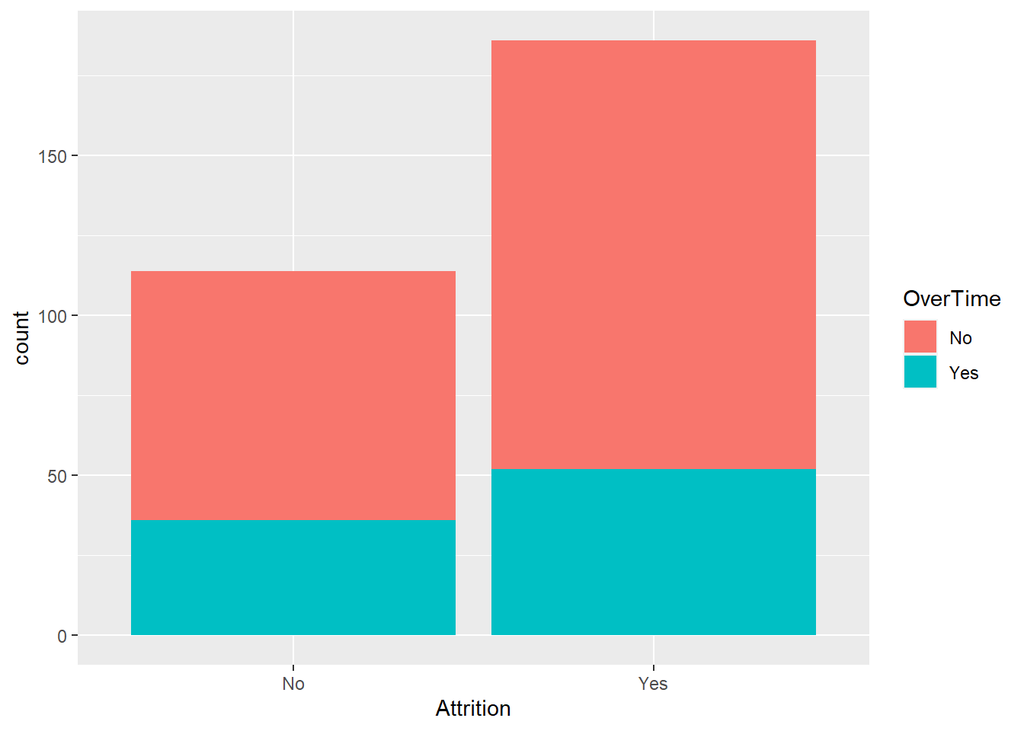

```r
df_knn_nattr %>% ggplot(aes(x=Attrition,fill=OverTime))+geom_bar()
```

```r
#Creating the prediction file
df_file_pre = data.frame(ID=df_knn_nattr$EmployeeId,Attrition=df_knn_nattr$Attrition)
write.csv(df_file_pre,main_data_file_noattr,row.names = FALSE)

write.csv(df_std_nattr,main_data_file_noattr_source,row.names = FALSE)



# test_ind = filter(df_predict_ds,ID ==1210)
# #test_ind_1 = select(test_ind,MonthlyIncomeScaled,YearsAtCompany,OverTimeN,JobLevelN,MaritalStatusN,StockOptionLevelN,JobSatisfaction)
# test_ind_2 = select(test_ind,MonthlyIncomeScaled,OverTimeN,JobLevelN,StockOptionLevelN,MaritalStatusN,YearsAtCompany)
# knn_nattr2 = knn(df_data_model_0[,c(2:7)], test_ind_2, df_data_model_0$Attrition, k = 3,prob = TRUE)
# knn_nattr2
# test_ind_2
```

### **Predict Monthly Income using Lineal regression model**

Predicting montyly income from file: CaseStudy2CompSet No Salary.csv

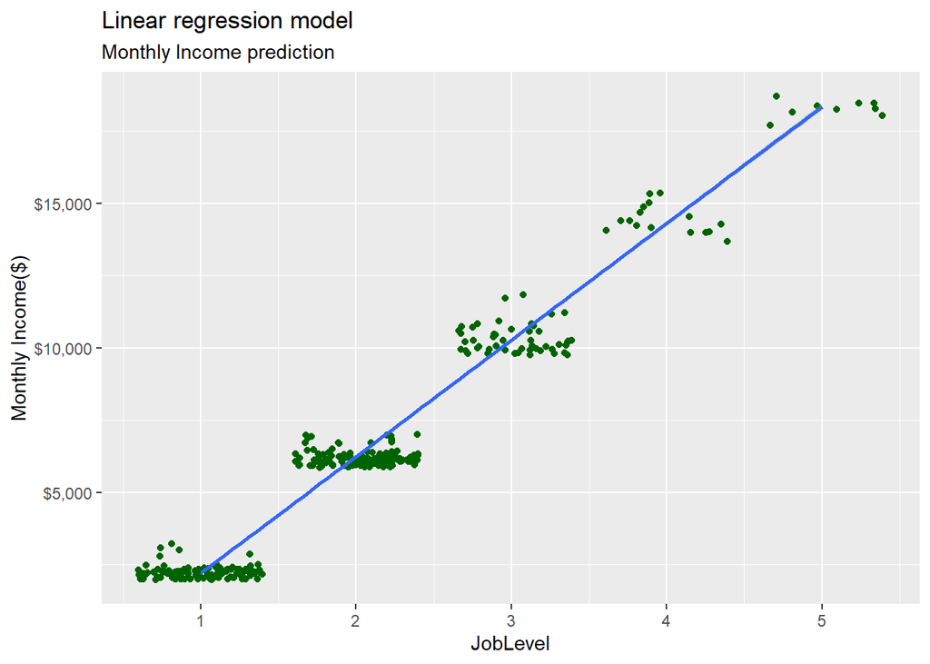

```r
df_train_lm = select(df_std_1,MonthlyIncome,JobLevelN2,YearsAtCompany,TotalWorkingYears)
df_test_lm = select(df_std_mi,JobLevel,YearsAtCompany,TotalWorkingYears)
df_test_lm$YearsAtCompany = as.numeric(df_test_lm$YearsAtCompany)
df_test_lm$TotalWorkingYears = as.numeric(df_test_lm$TotalWorkingYears)
df_test_lm$JobLevelN2 = as.numeric(factor(df_test_lm$JobLevel))


lm_model_0 = lm(MonthlyIncome~JobLevelN2+YearsAtCompany+TotalWorkingYears,data = df_std_1)
lm_model_pre_0 = predict(lm_model_0,newdata = df_test_lm)

#Resulting dataset
df_model_result = data.frame(EmployeeId = df_std_mi$ID,JobLevel = df_std_mi$JobLevel,YearsAtCompany=df_std_mi$YearsAtCompany,MonthlyIncome=lm_model_pre_0)
df_model_result$JobLevelN = as.numeric(factor(df_model_result$JobLevel))
df_model_result$MonthlyIncome = round(df_model_result$MonthlyIncome,2)


df_model_result %>% ggplot(aes(x=JobLevelN,y=MonthlyIncome))+geom_jitter(color="darkgreen")+
  scale_y_continuous(labels=scales::dollar)+labs(title = "Linear regression model",subtitle = "Monthly Income prediction",x="JobLevel",y="Monthly Income($)")+geom_smooth(method="lm")
```

```r
#Creating the prediction file
df_file_pre_mi = data.frame(ID=df_model_result$EmployeeId,MonthlyIncome=df_model_result$MonthlyIncome)
write.csv(df_file_pre_mi,main_data_file_mi,row.names = FALSE)
```

### **Business Insight**

- People working overtime and roles
- Job Level and Income
- Maritial Status and Young People

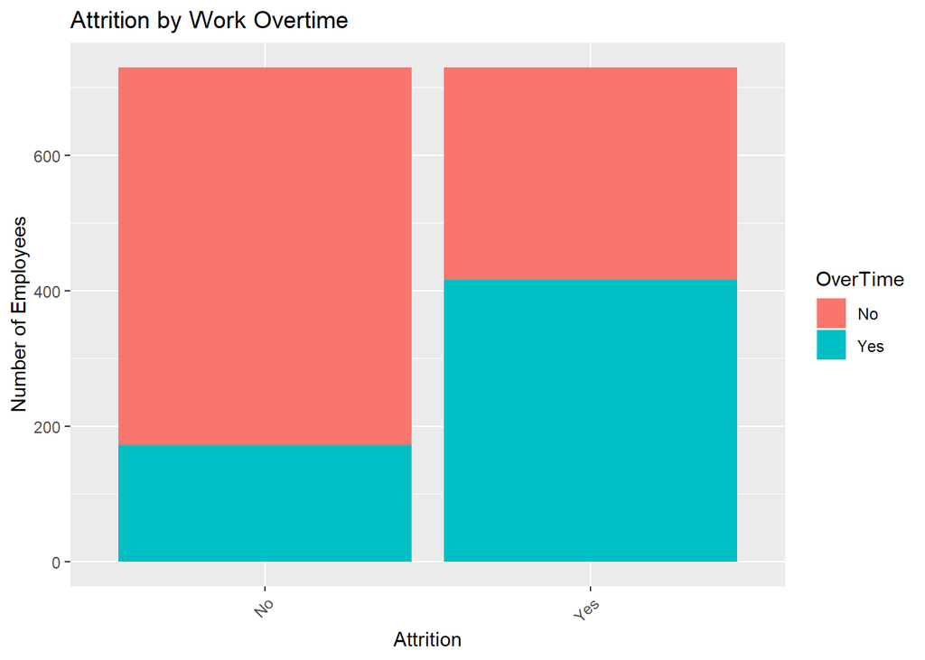

```r
#People working overtime and Roles overtime
df_std_unp %>% ggplot(aes(x=Attrition,fill=OverTime))+geom_bar()+theme(axis.text.x = element_text(angle = 45,hjust=1))+labs(title = "Attrition by Work Overtime",x="Attrition",y="Number of Employees")
```

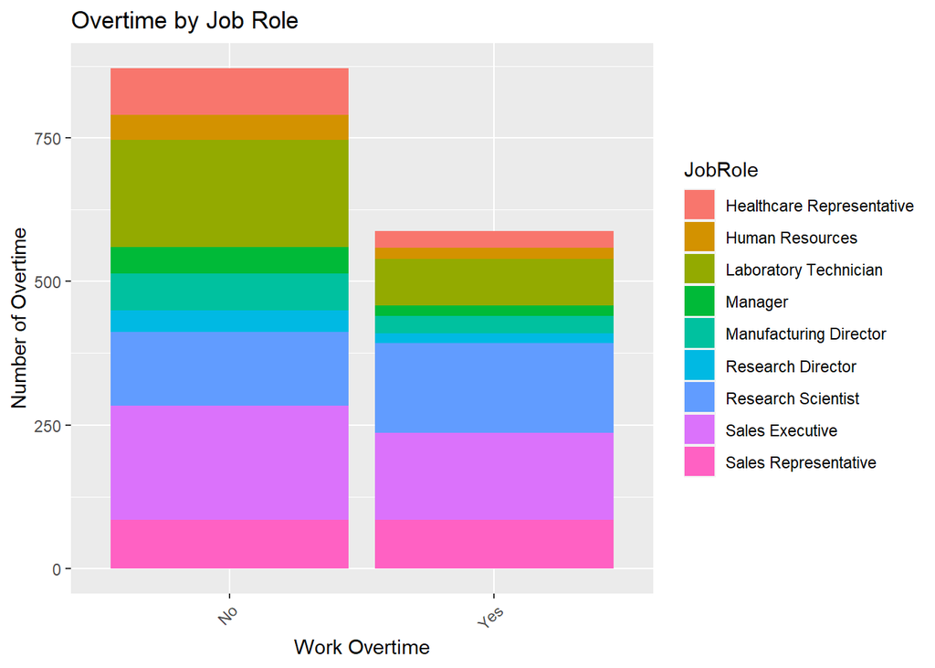

```r
  df_std_unp %>% ggplot(aes(x=OverTime,fill=JobRole))+geom_bar()+theme(axis.text.x = element_text(angle = 45,hjust=1))+labs(title = "Overtime by Job Role",x="Work Overtime",y="Number of Overtime")
```

```r
res = table(df_std_unp$JobRole,df_std_unp$Attrition)
round(prop.table(res,2),4)*100
```

```
##
##                                No   Yes
##   Healthcare Representative  9.32  5.89
##   Human Resources            2.88  5.75
##   Laboratory Technician     16.85 19.86
##   Manager                    6.44  2.33
##   Manufacturing Director    11.64  1.37
##   Research Director          6.85  0.55
##   Research Scientist        19.18 20.00
##   Sales Executive           22.88 24.93
##   Sales Representative       3.97 19.32
```

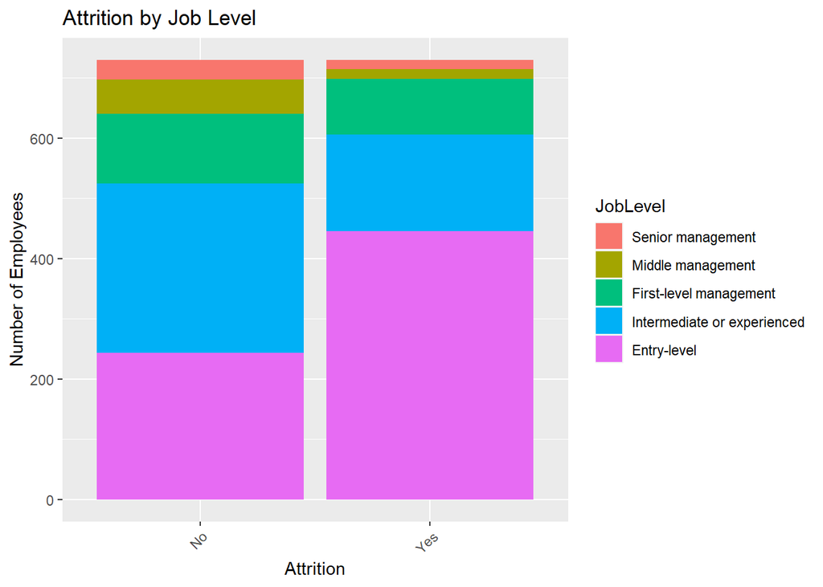

```r
#Job Level and Monthly Income
df_std_unp %>% ggplot(aes(x=Attrition,fill=JobLevel))+geom_bar()+theme(axis.text.x = element_text(angle = 45,hjust=1))+labs(title = "Attrition by Job Level",x="Attrition",y="Number of Employees")
```

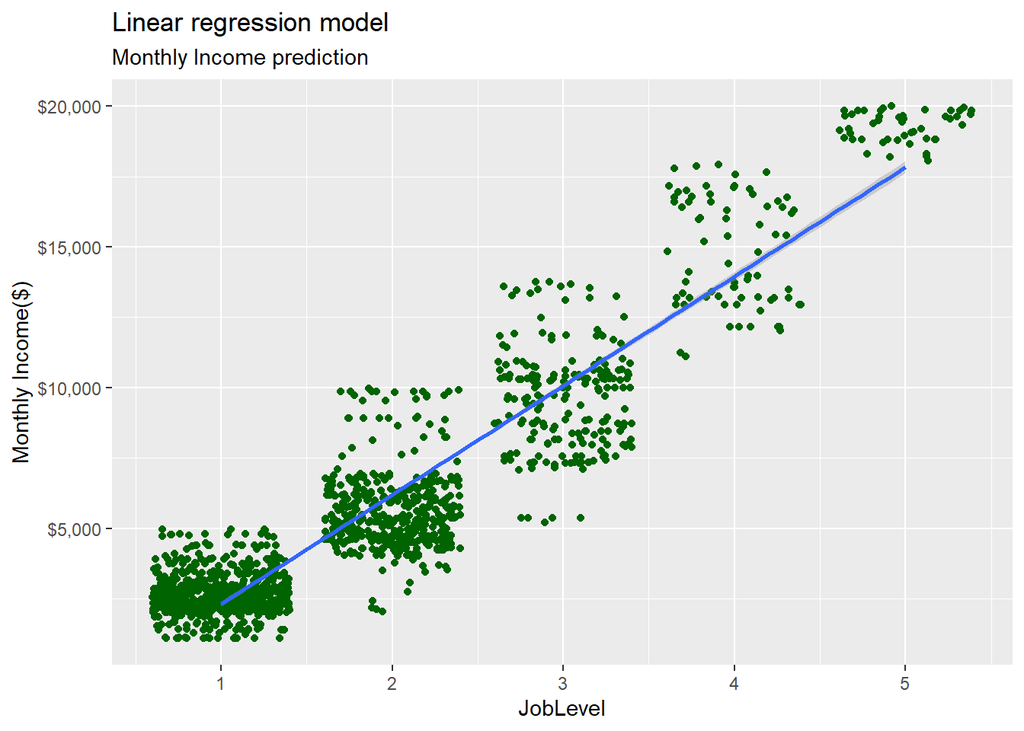

```r
df_std_unp %>% ggplot(aes(x=JobLevelN2,y=MonthlyIncome))+geom_jitter(color="darkgreen")+geom_smooth(method = "lm",aes(x=JobLevelN2,y=MonthlyIncome))+labs(title = "Linear regression model",subtitle = "Monthly Income prediction",x="JobLevel",y="Monthly Income($)")+scale_y_continuous(labels=scales::dollar)
```

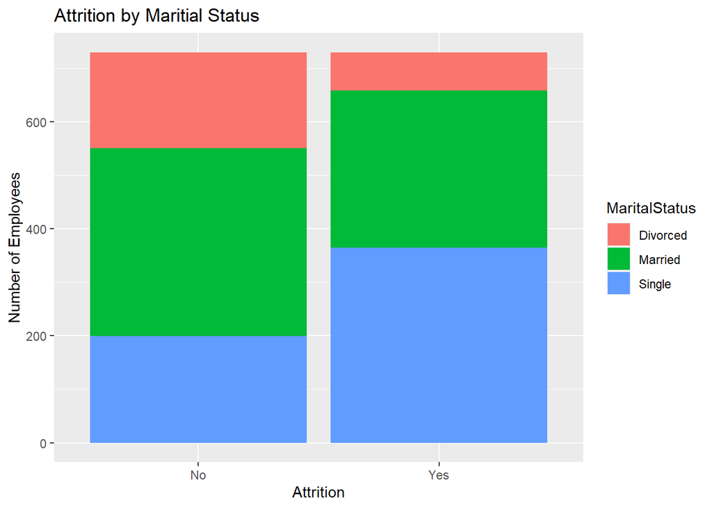

```r
#Maritial Status
df_std_unp %>% ggplot(aes(x=Attrition,fill=MaritalStatus))+geom_bar()+labs(title = "Attrition by Maritial Status",x="Attrition",y="Number of Employees")
```

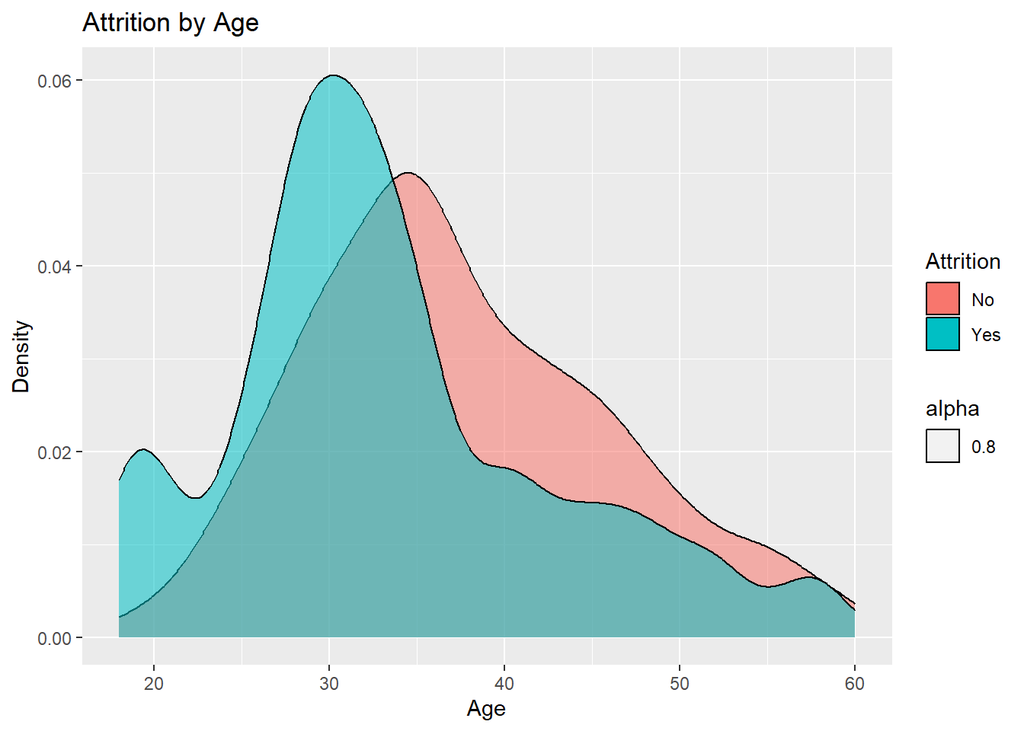

```r
df_std_unp %>% ggplot(aes(x=Age,fill=Attrition))+geom_density(aes(alpha=0.8))+labs(title = "Attrition by Age",x="Age",y="Density")
```

#### **Conclusion**

Recommendations:

- Reduce the working overtime especially for Research scientist and Sales Executive
- Increase the salary of the new employees
- Create more incentives for young people
- Provide more Training programs
- Provide more benefits such as health insurance coverage
- Provide more discounts in entertaining places
- Create a more positive environment